# Numerical Operation - Statistical Analysis

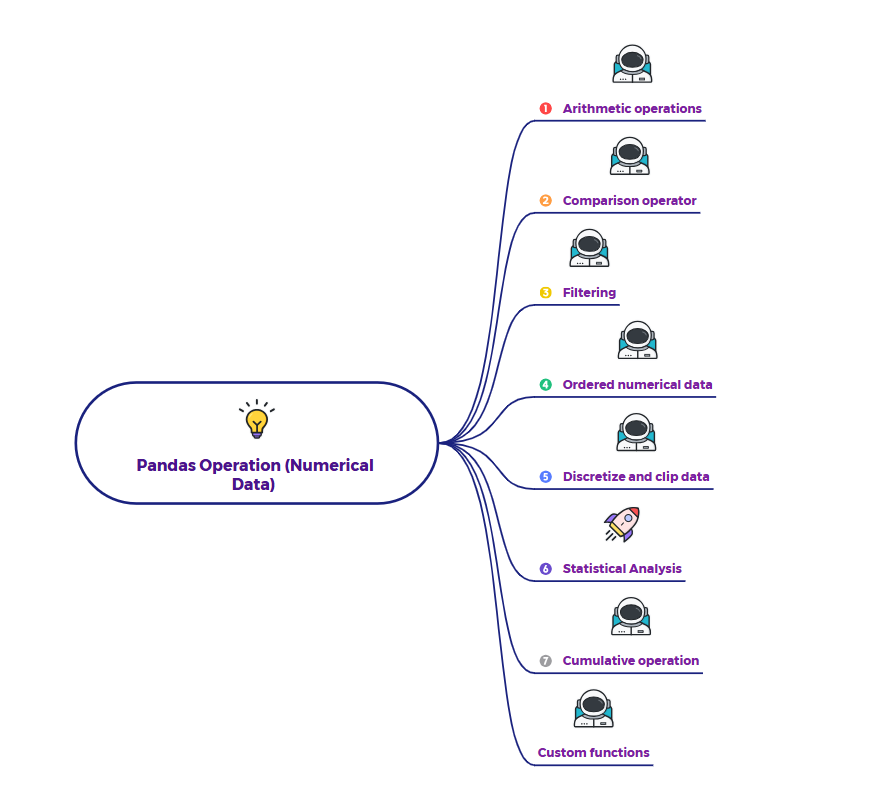

# Notebook Walkthrough -

- Import the required dataset and Viewing / Inspecting Dataset
- Statistical Analysis
- Statistical Analysis - Central tendency of the data
- Statistical Analysis - Measures of dispersion or variability
- Statistical Analysis - Understanding of Distribution
- Statistical Analysis - Pairwise relationship

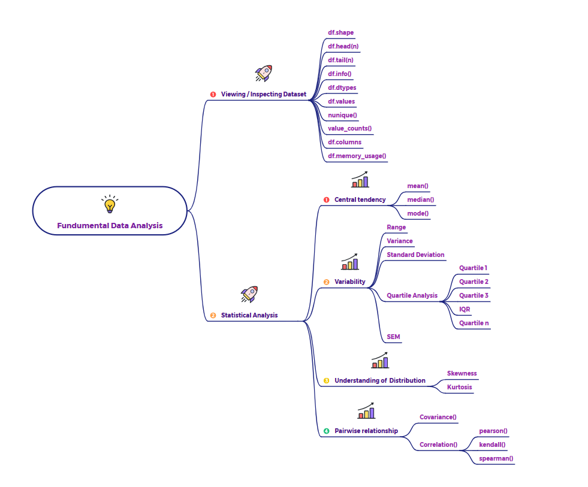

# 1. Import the required dataset and Viewing / Inspecting Dataset

```python
import pandas as pd
import numpy as np

df = pd.read_csv("IncomeData.csv")
```

### A. Shape of the dataset

```python
df.shape
```

```
(32561, 14)
```

```python
# (32561, 14) means 32561(rows) and 14(columns)
```

### B. Top n rows of the dataframe

```python
df.head()
```

|  | Age | Workclass | fnlwgt | Education | Education-Num | Marital Status | Occupation | Relationship | Sex | Capital Gain | Capital Loss | Hours per week | Country | Income |
| --- | --- | --- | --- | --- | --- | --- | --- | --- | --- | --- | --- | --- | --- | --- |
| 0 | 39 | State-gov | 77516 | Bachelors | 13 | Never-married | Adm-clerical | Not-in-family | Male | 2174 | 0 | 40 | United-States | <=50K |
| 1 | 50 | Self-emp-not-inc | 83311 | Bachelors | 13 | Married-civ-spouse | Exec-managerial | Husband | Male | 0 | 0 | 13 | United-States | <=50K |
| 2 | 38 | Private | 215646 | HS-grad | 9 | Divorced | Handlers-cleaners | Not-in-family | Male | 0 | 0 | 40 | United-States | <=50K |
| 3 | 53 | Private | 234721 | 11th | 7 | Married-civ-spouse | Handlers-cleaners | Husband | Male | 0 | 0 | 40 | United-States | <=50K |
| 4 | 28 | Private | 338409 | Bachelors | 13 | Married-civ-spouse | Prof-specialty | Wife | Female | 0 | 0 | 40 | Cuba | <=50K |

```python
df.head(10)
```

|  | Age | Workclass | fnlwgt | Education | Education-Num | Marital Status | Occupation | Relationship | Sex | Capital Gain | Capital Loss | Hours per week | Country | Income |
| --- | --- | --- | --- | --- | --- | --- | --- | --- | --- | --- | --- | --- | --- | --- |
| 0 | 39 | State-gov | 77516 | Bachelors | 13 | Never-married | Adm-clerical | Not-in-family | Male | 2174 | 0 | 40 | United-States | <=50K |
| 1 | 50 | Self-emp-not-inc | 83311 | Bachelors | 13 | Married-civ-spouse | Exec-managerial | Husband | Male | 0 | 0 | 13 | United-States | <=50K |
| 2 | 38 | Private | 215646 | HS-grad | 9 | Divorced | Handlers-cleaners | Not-in-family | Male | 0 | 0 | 40 | United-States | <=50K |
| 3 | 53 | Private | 234721 | 11th | 7 | Married-civ-spouse | Handlers-cleaners | Husband | Male | 0 | 0 | 40 | United-States | <=50K |
| 4 | 28 | Private | 338409 | Bachelors | 13 | Married-civ-spouse | Prof-specialty | Wife | Female | 0 | 0 | 40 | Cuba | <=50K |
| 5 | 37 | Private | 284582 | Masters | 14 | Married-civ-spouse | Exec-managerial | Wife | Female | 0 | 0 | 40 | United-States | <=50K |
| 6 | 49 | Private | 160187 | 9th | 5 | Married-spouse-absent | Other-service | Not-in-family | Female | 0 | 0 | 16 | Jamaica | <=50K |
| 7 | 52 | Self-emp-not-inc | 209642 | HS-grad | 9 | Married-civ-spouse | Exec-managerial | Husband | Male | 0 | 0 | 45 | United-States | >50K |
| 8 | 31 | Private | 45781 | Masters | 14 | Never-married | Prof-specialty | Not-in-family | Female | 14084 | 0 | 50 | United-States | >50K |
| 9 | 42 | Private | 159449 | Bachelors | 13 | Married-civ-spouse | Exec-managerial | Husband | Male | 5178 | 0 | 40 | United-States | >50K |

### C. Bottom n rows of the dataframe

```python
df.tail()
```

|  | Age | Workclass | fnlwgt | Education | Education-Num | Marital Status | Occupation | Relationship | Sex | Capital Gain | Capital Loss | Hours per week | Country | Income |
| --- | --- | --- | --- | --- | --- | --- | --- | --- | --- | --- | --- | --- | --- | --- |
| 32556 | 27 | Private | 257302 | Assoc-acdm | 12 | Married-civ-spouse | Tech-support | Wife | Female | 0 | 0 | 38 | United-States | <=50K |
| 32557 | 40 | Private | 154374 | HS-grad | 9 | Married-civ-spouse | Machine-op-inspct | Husband | Male | 0 | 0 | 40 | United-States | >50K |
| 32558 | 58 | Private | 151910 | HS-grad | 9 | Widowed | Adm-clerical | Unmarried | Female | 0 | 0 | 40 | United-States | <=50K |
| 32559 | 22 | Private | 201490 | HS-grad | 9 | Never-married | Adm-clerical | Own-child | Male | 0 | 0 | 20 | United-States | <=50K |
| 32560 | 52 | Self-emp-inc | 287927 | HS-grad | 9 | Married-civ-spouse | Exec-managerial | Wife | Female | 15024 | 0 | 40 | United-States | >50K |

```python
df.tail(10)
```

|  | Age | Workclass | fnlwgt | Education | Education-Num | Marital Status | Occupation | Relationship | Sex | Capital Gain | Capital Loss | Hours per week | Country | Income |
| --- | --- | --- | --- | --- | --- | --- | --- | --- | --- | --- | --- | --- | --- | --- |
| 32551 | 32 | Private | 34066 | 10th | 6 | Married-civ-spouse | Handlers-cleaners | Husband | Male | 0 | 0 | 40 | United-States | <=50K |
| 32552 | 43 | Private | 84661 | Assoc-voc | 11 | Married-civ-spouse | Sales | Husband | Male | 0 | 0 | 45 | United-States | <=50K |
| 32553 | 32 | Private | 116138 | Masters | 14 | Never-married | Tech-support | Not-in-family | Male | 0 | 0 | 11 | Taiwan | <=50K |
| 32554 | 53 | Private | 321865 | Masters | 14 | Married-civ-spouse | Exec-managerial | Husband | Male | 0 | 0 | 40 | United-States | >50K |
| 32555 | 22 | Private | 310152 | Some-college | 10 | Never-married | Protective-serv | Not-in-family | Male | 0 | 0 | 40 | United-States | <=50K |
| 32556 | 27 | Private | 257302 | Assoc-acdm | 12 | Married-civ-spouse | Tech-support | Wife | Female | 0 | 0 | 38 | United-States | <=50K |
| 32557 | 40 | Private | 154374 | HS-grad | 9 | Married-civ-spouse | Machine-op-inspct | Husband | Male | 0 | 0 | 40 | United-States | >50K |
| 32558 | 58 | Private | 151910 | HS-grad | 9 | Widowed | Adm-clerical | Unmarried | Female | 0 | 0 | 40 | United-States | <=50K |
| 32559 | 22 | Private | 201490 | HS-grad | 9 | Never-married | Adm-clerical | Own-child | Male | 0 | 0 | 20 | United-States | <=50K |
| 32560 | 52 | Self-emp-inc | 287927 | HS-grad | 9 | Married-civ-spouse | Exec-managerial | Wife | Female | 15024 | 0 | 40 | United-States | >50K |

### D. Dataframe schema information

df.info() gives you a concise summary of the DataFrame's schema, including:

- What columns are present ?
- The type of data each column holds ?
- How complete the data is ?
- How much memory the DataFrame is using ?

```python
df.info()
```

```
<class 'pandas.core.frame.DataFrame'>
RangeIndex: 32561 entries, 0 to 32560
Data columns (total 14 columns):
 #   Column          Non-Null Count  Dtype
---  ------          --------------  -----
 0   Age             32561 non-null  int64
 1   Workclass       30725 non-null  object
 2   fnlwgt          32561 non-null  int64
 3   Education       32561 non-null  object
 4   Education-Num   32561 non-null  int64
 5   Marital Status  32561 non-null  object
 6   Occupation      30718 non-null  object
 7   Relationship    32561 non-null  object
 8   Sex             32561 non-null  object
 9   Capital Gain    32561 non-null  int64
 10  Capital Loss    32561 non-null  int64
 11  Hours per week  32561 non-null  int64
 12  Country         31978 non-null  object
 13  Income          32561 non-null  object
dtypes: int64(6), object(8)
memory usage: 3.5+ MB
```

### E. Dataframe index information

This output indicates that you have a RangeIndex in Pandas, which is a type of index commonly used for DataFrames. Let's break down what each part means:

- RangeIndex: This is a special type of index in Pandas that represents an immutable sequence of integers. It's often used as the default index for DataFrames when you don't explicitly specify one.
- start=0: This means the index starts at the integer 0.
- stop=32561: This means the index ends before the integer 32561. So, the last value in the index will be 32560.
- step=1: This means the index increments by 1 for each subsequent value (0, 1, 2, 3, ...).
- In essence, this RangeIndex represents a sequence of integers from 0 to 32560 (inclusive).

```python
df.index
```

```
RangeIndex(start=0, stop=32561, step=1)
```

### F. Datatypes of each columns

Returns a Pandas Series: df.dtypes returns a Series where:

- The index is the column names of the DataFrame.
- The values are the data types of the corresponding columns.
- Data Type Information: The data types are represented using Pandas' data type objects (e.g., int64, float64, object, datetime64[ns], bool, category).

```python
df.dtypes
```

|  | 0 |
| --- | --- |
| Age | int64 |
| Workclass | object |
| fnlwgt | int64 |
| Education | object |
| Education-Num | int64 |
| Marital Status | object |
| Occupation | object |
| Relationship | object |
| Sex | object |
| Capital Gain | int64 |
| Capital Loss | int64 |
| Hours per week | int64 |
| Country | object |
| Income | object |

**dtype:** object

### G. Numpy array representation of underlying data

Returns a NumPy array: df.values gives you a 2-dimensional NumPy array where:

- Each row in the array corresponds to a row in the DataFrame.
- Each column in the array corresponds to a column in the DataFrame.
- Excludes Index and Column Labels: The resulting array does not include the DataFrame's index or column labels. It only contains the raw data.

```python
df.values
```

```
array([[39, 'State-gov', 77516, ..., 40, 'United-States', '<=50K'],
       [50, 'Self-emp-not-inc', 83311, ..., 13, 'United-States', '<=50K'],
       [38, 'Private', 215646, ..., 40, 'United-States', '<=50K'],
       ...,
       [58, 'Private', 151910, ..., 40, 'United-States', '<=50K'],
       [22, 'Private', 201490, ..., 20, 'United-States', '<=50K'],
       [52, 'Self-emp-inc', 287927, ..., 40, 'United-States', '>50K']],
      dtype=object)
```

### H. Number of Unique values in a specific column ( Done mainly for Categorical Variable )

```python
print('Unique categories in Workclass is :' , df['Workclass'].nunique())
print('Unique categories in Education is :' , df['Education'].nunique())
print('Unique categories in Marital Status is :' , df['Marital Status'].nunique())
print('Unique categories in Occupation is :' , df['Occupation'].nunique())
print('Unique categories in Relationship is :' , df['Relationship'].nunique())
print('Unique categories in Sex is :' , df['Sex'].nunique())
print('Unique categories in Country is :' , df['Country'].nunique())
```

```
Unique categories in Workclass is : 8
Unique categories in Education is : 16
Unique categories in Marital Status is : 7
Unique categories in Occupation is : 14
Unique categories in Relationship is : 6
Unique categories in Sex is : 2
Unique categories in Country is : 41
```

### I. Distribution of Unique Values in Specific column

```python
print('Unique category distribution in Workclass is :' , df['Workclass'].value_counts())
print('='*100)
print('Unique category distribution in Education is :' , df['Education'].value_counts())
print('='*100)
print('Unique category distribution in Marital Status is :' , df['Marital Status'].value_counts())
print('='*100)
print('Unique category distribution in Occupation is :' , df['Occupation'].value_counts())
print('='*100)
print('Unique category distribution in Relationship is :' , df['Relationship'].value_counts())
print('='*100)
print('Unique category distribution in Sex is :' , df['Sex'].value_counts())
print('='*100)
print('Unique category distribution in Country is :' , df['Country'].value_counts())
```

```
Unique category distribution in Workclass is : Workclass
Private             22696
Self-emp-not-inc     2541
Local-gov            2093
State-gov            1298
Self-emp-inc         1116
Federal-gov           960
Without-pay            14
Never-worked            7
Name: count, dtype: int64
====================================================================================================
Unique category distribution in Education is : Education
HS-grad         10501
Some-college     7291
Bachelors        5355
Masters          1723
Assoc-voc        1382
11th             1175
Assoc-acdm       1067
10th              933
7th-8th           646
Prof-school       576
9th               514
12th              433
Doctorate         413
5th-6th           333
1st-4th           168
Preschool          51
Name: count, dtype: int64
====================================================================================================
Unique category distribution in Marital Status is : Marital Status
Married-civ-spouse       14976
Never-married            10683
Divorced                  4443
Separated                 1025
Widowed                    993
Married-spouse-absent      418
Married-AF-spouse           23
Name: count, dtype: int64
====================================================================================================
```

[output cut: 59 more lines]

```
Greece                           29
Ecuador                          28
Ireland                          24
Hong                             20
Trinadad&Tobago                  19
Cambodia                         19
Thailand                         18
Laos                             18
Yugoslavia                       16
Outlying-US(Guam-USVI-etc)       14
Honduras                         13
Hungary                          13
Scotland                         12
Holand-Netherlands                1
Name: count, dtype: int64
```

### I. List down the names of columns in the Dataframe

```python
df.columns
```

```
Index(['Age', 'Workclass', 'fnlwgt', 'Education', 'Education-Num',
       'Marital Status', 'Occupation', 'Relationship', 'Sex', 'Capital Gain',
       'Capital Loss', 'Hours per week', 'Country', 'Income'],
      dtype='object')
```

### J. Memory usage by the columns

```python
df.memory_usage(deep=True)
```

|  | 0 |
| --- | --- |
| Index | 132 |
| Age | 260488 |
| Workclass | 2064314 |
| fnlwgt | 260488 |
| Education | 2130587 |
| Education-Num | 260488 |
| Marital Status | 2325313 |
| Occupation | 2205365 |
| Relationship | 2152925 |
| Sex | 2007763 |
| Capital Gain | 260488 |
| Capital Loss | 260488 |
| Hours per week | 260488 |
| Country | 2241119 |
| Income | 2010941 |

**dtype:** int64

# 2. Statistical Analysis

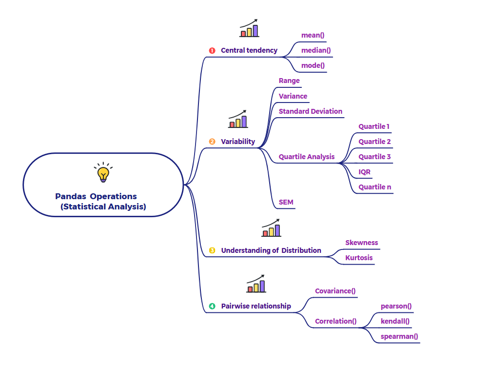

# 3. Statistical Analysis - Central tendency of the data

The central tendency of a dataset refers to a single, representative value that aims to describe the "center" or "typical" position of the data within its distribution. It summarizes the most characteristic or common score in a dataset, providing a concise measure around which the data points tend to cluster. The most common measures of central tendency are the mean (average), median (middle value), and mode (most frequent value), each offering a different perspective on the dataset's typical value.

### A. Describe the data - summary

```python
# df.describe() : Only highlights the numerical column

df.describe()
```

|  | Age | fnlwgt | Education-Num | Capital Gain | Capital Loss | Hours per week |
| --- | --- | --- | --- | --- | --- | --- |
| count | 32561.000000 | 3.256100e+04 | 32561.000000 | 32561.000000 | 32561.000000 | 32561.000000 |
| mean | 38.581647 | 1.897784e+05 | 10.080679 | 1077.648844 | 87.303830 | 40.437456 |
| std | 13.640433 | 1.055500e+05 | 2.572720 | 7385.292085 | 402.960219 | 12.347429 |
| min | 17.000000 | 1.228500e+04 | 1.000000 | 0.000000 | 0.000000 | 1.000000 |
| 25% | 28.000000 | 1.178270e+05 | 9.000000 | 0.000000 | 0.000000 | 40.000000 |
| 50% | 37.000000 | 1.783560e+05 | 10.000000 | 0.000000 | 0.000000 | 40.000000 |
| 75% | 48.000000 | 2.370510e+05 | 12.000000 | 0.000000 | 0.000000 | 45.000000 |
| max | 90.000000 | 1.484705e+06 | 16.000000 | 99999.000000 | 4356.000000 | 99.000000 |

```python
df.describe(include='number')
```

|  | Age | fnlwgt | Education-Num | Capital Gain | Capital Loss | Hours per week |
| --- | --- | --- | --- | --- | --- | --- |
| count | 32561.000000 | 3.256100e+04 | 32561.000000 | 32561.000000 | 32561.000000 | 32561.000000 |
| mean | 38.581647 | 1.897784e+05 | 10.080679 | 1077.648844 | 87.303830 | 40.437456 |
| std | 13.640433 | 1.055500e+05 | 2.572720 | 7385.292085 | 402.960219 | 12.347429 |
| min | 17.000000 | 1.228500e+04 | 1.000000 | 0.000000 | 0.000000 | 1.000000 |
| 25% | 28.000000 | 1.178270e+05 | 9.000000 | 0.000000 | 0.000000 | 40.000000 |
| 50% | 37.000000 | 1.783560e+05 | 10.000000 | 0.000000 | 0.000000 | 40.000000 |
| 75% | 48.000000 | 2.370510e+05 | 12.000000 | 0.000000 | 0.000000 | 45.000000 |
| max | 90.000000 | 1.484705e+06 | 16.000000 | 99999.000000 | 4356.000000 | 99.000000 |

```python
df.describe(include=['int64', 'float64'])
```

|  | Age | fnlwgt | Education-Num | Capital Gain | Capital Loss | Hours per week |
| --- | --- | --- | --- | --- | --- | --- |
| count | 32561.000000 | 3.256100e+04 | 32561.000000 | 32561.000000 | 32561.000000 | 32561.000000 |
| mean | 38.581647 | 1.897784e+05 | 10.080679 | 1077.648844 | 87.303830 | 40.437456 |
| std | 13.640433 | 1.055500e+05 | 2.572720 | 7385.292085 | 402.960219 | 12.347429 |
| min | 17.000000 | 1.228500e+04 | 1.000000 | 0.000000 | 0.000000 | 1.000000 |
| 25% | 28.000000 | 1.178270e+05 | 9.000000 | 0.000000 | 0.000000 | 40.000000 |
| 50% | 37.000000 | 1.783560e+05 | 10.000000 | 0.000000 | 0.000000 | 40.000000 |
| 75% | 48.000000 | 2.370510e+05 | 12.000000 | 0.000000 | 0.000000 | 45.000000 |
| max | 90.000000 | 1.484705e+06 | 16.000000 | 99999.000000 | 4356.000000 | 99.000000 |

```python
# if we want to describe categorical variables

df.describe(include='object')
#df.describe(include='O')
```

|  | Workclass | Education | Marital Status | Occupation | Relationship | Sex | Country | Income |
| --- | --- | --- | --- | --- | --- | --- | --- | --- |
| count | 30725 | 32561 | 32561 | 30718 | 32561 | 32561 | 31978 | 32561 |
| unique | 8 | 16 | 7 | 14 | 6 | 2 | 41 | 2 |
| top | Private | HS-grad | Married-civ-spouse | Prof-specialty | Husband | Male | United-States | <=50K |
| freq | 22696 | 10501 | 14976 | 4140 | 13193 | 21790 | 29170 | 24720 |

```python
# if you want to describe the complete dataset together

df.describe(include='all')
```

|  | Age | Workclass | fnlwgt | Education | Education-Num | Marital Status | Occupation | Relationship | Sex | Capital Gain | Capital Loss | Hours per week | Country | Income |
| --- | --- | --- | --- | --- | --- | --- | --- | --- | --- | --- | --- | --- | --- | --- |
| count | 32561.000000 | 30725 | 3.256100e+04 | 32561 | 32561.000000 | 32561 | 30718 | 32561 | 32561 | 32561.000000 | 32561.000000 | 32561.000000 | 31978 | 32561 |
| unique | NaN | 8 | NaN | 16 | NaN | 7 | 14 | 6 | 2 | NaN | NaN | NaN | 41 | 2 |
| top | NaN | Private | NaN | HS-grad | NaN | Married-civ-spouse | Prof-specialty | Husband | Male | NaN | NaN | NaN | United-States | <=50K |
| freq | NaN | 22696 | NaN | 10501 | NaN | 14976 | 4140 | 13193 | 21790 | NaN | NaN | NaN | 29170 | 24720 |
| mean | 38.581647 | NaN | 1.897784e+05 | NaN | 10.080679 | NaN | NaN | NaN | NaN | 1077.648844 | 87.303830 | 40.437456 | NaN | NaN |
| std | 13.640433 | NaN | 1.055500e+05 | NaN | 2.572720 | NaN | NaN | NaN | NaN | 7385.292085 | 402.960219 | 12.347429 | NaN | NaN |
| min | 17.000000 | NaN | 1.228500e+04 | NaN | 1.000000 | NaN | NaN | NaN | NaN | 0.000000 | 0.000000 | 1.000000 | NaN | NaN |
| 25% | 28.000000 | NaN | 1.178270e+05 | NaN | 9.000000 | NaN | NaN | NaN | NaN | 0.000000 | 0.000000 | 40.000000 | NaN | NaN |
| 50% | 37.000000 | NaN | 1.783560e+05 | NaN | 10.000000 | NaN | NaN | NaN | NaN | 0.000000 | 0.000000 | 40.000000 | NaN | NaN |
| 75% | 48.000000 | NaN | 2.370510e+05 | NaN | 12.000000 | NaN | NaN | NaN | NaN | 0.000000 | 0.000000 | 45.000000 | NaN | NaN |
| max | 90.000000 | NaN | 1.484705e+06 | NaN | 16.000000 | NaN | NaN | NaN | NaN | 99999.000000 | 4356.000000 | 99.000000 | NaN | NaN |

### B. Mean of the column

Let's say you have the following dataset of ages: 25, 30, 22, 28, 35.

Sum of all values: 25 + 30 + 22 + 28 + 35 = 140 Number of values: 5 Mean: 140 / 5 = 28 Therefore, the mean age in this dataset is 28.

Important Notes:

- The mean is sensitive to outliers (extreme values). A single very large or very small value can significantly affect the mean.
- The mean is typically used for datasets with a roughly symmetrical distribution. For skewed data, the median might be a more representative measure of central tendency.

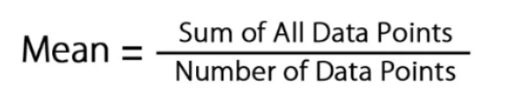

```python
print('Mean value of Age:' , df['Age'].mean())
print('Mean value of fnlwgt:' , df['fnlwgt'].mean())
print('Mean value of Education-Num:' , df['Education-Num'].mean())
print('Mean value of Capital Gain:' , df['Capital Gain'].mean())
print('Mean value of Capital Loss:' , df['Capital Loss'].mean())
print('Mean value of Hours per week:' , df['Hours per week'].mean())
```

```
Mean value of Age: 38.58164675532078
Mean value of fnlwgt: 189778.36651208502
Mean value of Education-Num: 10.0806793403151
Mean value of Capital Gain: 1077.6488437087312
Mean value of Capital Loss: 87.303829734959
Mean value of Hours per week: 40.437455852092995
```

### Interpretation

- The average age in the dataset is approximately 38.6 years, suggesting a middle-aged population.
- The mean fnlwgt (final weight, an internal census bureau term) is around 189,778, indicating a relatively large average number of people represented by each record.
- On average, individuals have completed about 10.1 years of education, which often corresponds to some college or an associate's degree.
- The mean capital gain is quite low, around 1077.6, implying that most individuals have little to no capital gains or that large gains are infrequent.
- Similarly, the mean capital loss is very low, approximately 87.3, suggesting that capital losses are also generally small or rare within this dataset.
- On average, individuals work roughly 40.4 hours per week, which aligns closely with a standard full-time work schedule.

### C. Median of the columns

The median is the middle value in a dataset that has been sorted in ascending order. It separates the lower half of the data from the upper half.

Here's how to calculate the median:

- Sort the data: Arrange the values in ascending order (from smallest to largest).
- Find the middle:
  - If the dataset has an odd number of values: The median is the middle value. * If the dataset has an even number of values: The median is the average of the two middle values.

Examples:

- Odd number of values:

Dataset: 22, 25, 28, 30, 35

Sorted data: 22, 25, 28, 30, 35

Median: 28

- Even number of values:

Dataset: 22, 25, 28, 30

Sorted data: 22, 25, 28, 30 Median: (25 + 28) / 2 = 26.5

Important Notes:

- The median is less affected by outliers than the mean.
- Extreme values don't influence the middle value as much.
- The median is often used for datasets with skewed distributions, where the mean might be misleading.
- In Pandas, you can calculate the median of a DataFrame or Series using the df.median() method.
- It handles NaN (Not a Number) values by ignoring them.

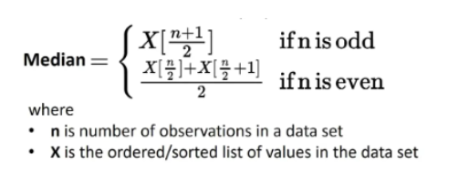

```python
print('Median value of Age:' , df['Age'].median())
print('Median value of fnlwgt:' , df['fnlwgt'].median())
print('Median value of Education-Num:' , df['Education-Num'].median())
print('Median value of Capital Gain:' , df['Capital Gain'].median())
print('Median value of Capital Loss:' , df['Capital Loss'].median())
print('Median value of Hours per week:' , df['Hours per week'].median())
```

```
Median value of Age: 37.0
Median value of fnlwgt: 178356.0
Median value of Education-Num: 10.0
Median value of Capital Gain: 0.0
Median value of Capital Loss: 0.0
Median value of Hours per week: 40.0
```

### Interpretation

- The median age is 37.0 years, meaning half of the individuals in the dataset are younger than 37 and half are older.
- The median fnlwgt is 178,356, indicating that half of the records represent fewer than this number of people and half represent more.
- The median Education-Num is 10.0, suggesting that at least half of the individuals have completed exactly 10 years of education or less.
- Both the median Capital Gain and median Capital Loss are 0.0, strongly indicating that the vast majority of individuals in this dataset have experienced no capital gains or losses.
- The median Hours per week is 40.0, which means that exactly half of the individuals work 40 hours per week or less, and half work 40 hours or more.
- The presence of 0.0 for both median capital gain and loss suggests a heavily skewed distribution for these variables, with many values at zero.

### D. Mode

The mode is the value that appears most frequently in a dataset. A dataset can have one mode (unimodal), more than one mode (multimodal), or no mode at all if all values occur with the same frequency.

Here's how to calculate the mode:

Count occurrences: Determine how many times each value appears in the dataset. Identify the most frequent: The value(s) with the highest count is/are the mode(s).

Examples:

- Unimodal:

Dataset: 22, 25, 28, 30, 35, 25

- 22 appears once.
- 25 appears twice.
- 28 appears once.
- 30 appears once.
- 35 appears once.

Mode: 25

- Multimodal:

Dataset: 22, 25, 28, 30, 25, 28

- 22 appears once.
- 25 appears twice.
- 28 appears twice.
- 30 appears once.

Modes: 25 and 28

- No mode:

Dataset: 22, 25, 28, 30

All values appear once.

Mode: None

Important Notes:

The mode is the only measure of central tendency that can be used for categorical data (e.g., colors, types of fruit). A dataset can have no mode, one mode, or multiple modes. In Pandas, you can calculate the mode of a DataFrame or Series using the df.mode() method.

```python
print('Mode value of Workclass:', df['Workclass'].mode())
print('Mode value of Education:' , df['Education'].mode())
print('Mode value of Marital Status:' , df['Marital Status'].mode())
print('Mode value of Relationship:' , df['Relationship'].mode())
print('Mode value of Sex:' , df['Sex'].mode())
print('Mode value of Country:' , df['Country'].mode())
print('Mode value of Income:' , df['Income'].mode())
print('Mode value of Occupation:' , df['Occupation'].mode())
```

```
Mode value of Workclass: 0    Private
Name: Workclass, dtype: object
Mode value of Education: 0    HS-grad
Name: Education, dtype: object
Mode value of Marital Status: 0    Married-civ-spouse
Name: Marital Status, dtype: object
Mode value of Relationship: 0    Husband
Name: Relationship, dtype: object
Mode value of Sex: 0    Male
Name: Sex, dtype: object
Mode value of Country: 0    United-States
Name: Country, dtype: object
Mode value of Income: 0    <=50K
Name: Income, dtype: object
Mode value of Occupation: 0    Prof-specialty
Name: Occupation, dtype: object
```

# 4. Statistical Analysis - Measures of dispersion or variability

Measures of dispersion (or variability) quantify the spread or scattering of data points around the central tendency of a dataset. Instead of describing where the data is centered, these metrics indicate how much the individual data values differ from each other and from the average. A high measure of dispersion suggests that data points are widely spread out, implying greater diversity or volatility, while a low measure indicates that data points are tightly clustered together, suggesting consistency or homogeneity.

### A. Minimum , Maximum value and range of a numerical variable

```python
print('Minimum value of Age:' , df['Age'].min())
print('Minimum value of fnlwgt:' , df['fnlwgt'].min())
print('Minimum value of Education-Num:' , df['Education-Num'].min())
print('Minimum value of Capital Gain:' , df['Capital Gain'].min())
print('Minimum value of Capital Loss:' , df['Capital Loss'].min())
print('Minimum value of Hours per week:' , df['Hours per week'].min())
```

```
Minimum value of Age: 17
Minimum value of fnlwgt: 12285
Minimum value of Education-Num: 1
Minimum value of Capital Gain: 0
Minimum value of Capital Loss: 0
Minimum value of Hours per week: 1
```

```python
print('Maximum value of Age:' , df['Age'].max())
print('Maximum value of fnlwgt:' , df['fnlwgt'].max())
print('Maximum value of Education-Num:' , df['Education-Num'].max())
print('Maximum value of Capital Gain:' , df['Capital Gain'].max())
print('Maximum value of Capital Loss:' , df['Capital Loss'].max())
print('Maximum value of Hours per week:' , df['Hours per week'].max())
```

```
Maximum value of Age: 90
Maximum value of fnlwgt: 1484705
Maximum value of Education-Num: 16
Maximum value of Capital Gain: 99999
Maximum value of Capital Loss: 4356
Maximum value of Hours per week: 99
```

```python
print('Range of Age:' , (df['Age'].max()-df['Age'].min()))
print('Range of fnlwgt:' , (df['fnlwgt'].max()-df['fnlwgt'].min()))
print('Range of Education-Num:' , (df['Education-Num'].max()-df['Education-Num'].min()))
print('Range of Capital Gain:' , (df['Capital Gain'].max()-df['Capital Gain'].min()))
print('Range of Capital Loss:' , (df['Capital Loss'].max()-df['Capital Loss'].min()))
print('Range of Hours per week:' , (df['Hours per week'].max()-df['Hours per week'].min()))
```

```
Range of Age: 73
Range of fnlwgt: 1472420
Range of Education-Num: 15
Range of Capital Gain: 99999
Range of Capital Loss: 4356
Range of Hours per week: 98
```

### Interpretation

- The Age in the dataset spans from 17 to 90 years, covering a very wide age group with a range of 73 years.
- The fnlwgt (final weight) shows an extremely broad range, from 12,285 to 1,484,705, indicating significant variability in the number of people each record represents.
- Education-Num varies from 1 to 16, suggesting that the dataset includes individuals with very little formal education (possibly primary school) up to those with advanced degrees (e.g., 16 often represents a Doctorate).
- Capital Gain has a minimum of 0 and a maximum of 99,999, with a range of 99,999. This indicates that while many individuals have no capital gain (as seen from median), there are also instances of very substantial capital gains.
- Similarly, Capital Loss ranges from 0 to 4,356, with a maximum of 4,356. This pattern mirrors capital gain, where most have no loss, but some individuals experience notable losses.
- Hours per week ranges from a minimum of 1 hour to a maximum of 99 hours, showing a diverse spectrum of work commitments, from very part-time to extremely long working hours.

### B. Standard Deviation

Example:

Let's say you have the following dataset: 2, 4, 6, 8

Calculate the Mean: (2 + 4 + 6 + 8) / 4 = 5

Calculate the Variance:

- (2 - 5)² = 9
- (4 - 5)² = 1
- (6 - 5)² = 1
- (8 - 5)² = 9
- (9 + 1 + 1 + 9) / 4 = 5 (Variance)

Calculate the Standard Deviation:

√5 ≈ 2.236

Key points:

A higher standard deviation means the data is more spread out. A lower standard deviation means the data is more clustered around the mean. Standard deviation is very important in statistical analysis, helping us understand the distribution of data.

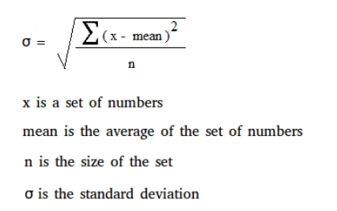

```python
print('Standard Deviation of Age:' , df['Age'].std())
print('Standard Deviation of fnlwgt:' , df['fnlwgt'].std())
print('Standard Deviation of Education-Num:' , df['Education-Num'].std())
print('Standard Deviation of Capital Gain:' , df['Capital Gain'].std())
print('Standard Deviation of Capital Loss:' , df['Capital Loss'].std())
print('Standard Deviation of Hours per week:' , df['Hours per week'].std())
```

```
Standard Deviation of Age: 13.640432553581146
Standard Deviation of fnlwgt: 105549.97769702233
Standard Deviation of Education-Num: 2.5727203320673406
Standard Deviation of Capital Gain: 7385.292084839299
Standard Deviation of Capital Loss: 402.960218649059
Standard Deviation of Hours per week: 12.34742868173081
```

### Interpretation

- The Standard Deviation of Age is approximately 13.64 years. This indicates a moderate spread in ages, meaning that individual ages tend to deviate from the average age by about 13.64 years.
- The Standard Deviation of fnlwgt is very high, around 105,550. This suggests a very wide dispersion in how many people each record represents, indicating significant variability in the fnlwgt values.
- The Standard Deviation of Education-Num is about 2.57 years. This is a relatively small spread, meaning most individuals' years of education are clustered fairly closely around the mean.
- The Standard Deviation of Capital Gain is very large, approximately 7385.29. This, combined with the low mean and zero median, strongly implies that while most people have zero capital gain, a few individuals have extremely high capital gains, pulling the standard deviation up significantly.
- Similarly, the Standard Deviation of Capital Loss is high at around 402.96. Like capital gain, this points to a situation where most people have no capital loss, but a few have relatively large losses, leading to high variability.
- The Standard Deviation of Hours per week is about 12.35 hours. This indicates a noticeable spread in the number of hours people work, suggesting that while the average is around 40 hours, there's a significant portion of the population working considerably more or less than that.

### C. Variation

Example:

Let's say your dataset is: [2, 4, 6, 8]

Calculate the Mean: (2 + 4 + 6 + 8) / 4 = 5

Calculate the Squared Differences:

- (2 - 5)² = 9
- (4 - 5)² = 1
- (6 - 5)² = 1
- (8 - 5)² = 9

Calculate the Variance:

(9 + 1 + 1 + 9) / 4 = 5

So, the variance of the dataset [2, 4, 6, 8] is 5.

Key Points:

Variance measures how much the data points deviate from the mean. A higher variance indicates that the data is more spread out. A lower variance indicates that the data is more clustered around the mean. Variance is always a non-negative value. The square root of the variance gives you the standard deviation, which is another common measure of dispersion.

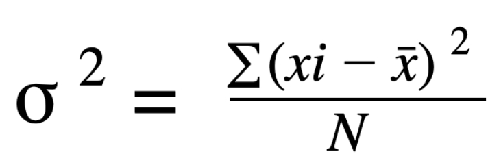

```python
print('Variation of Age:' , df['Age'].var())
print('Variation of fnlwgt:' , df['fnlwgt'].var())
print('Variation of Education-Num:' , df['Education-Num'].var())
print('Variation of Capital Gain:' , df['Capital Gain'].var())
print('Variation of Capital Loss:' , df['Capital Loss'].var())
print('Variation of Hours per week:' , df['Hours per week'].var())
```

```
Variation of Age: 186.06140024879625
Variation of fnlwgt: 11140797791.841913
Variation of Education-Num: 6.618889907032687
Variation of Capital Gain: 54542539.17839
Variation of Capital Loss: 162376.93781369744
Variation of Hours per week: 152.45899505042865
```

### Interpretation

- Variation of Age (186.06): This indicates a moderate spread in the ages of individuals. Since the unit of variance is squared, it's not directly interpretable in "years," but relative to other variables, it suggests a reasonable diversity in age within the dataset.
- Variation of fnlwgt (11,140,797,791.84): This is an extremely large variance. Given fnlwgt often represents population estimates, this huge number signifies an enormous spread in the "final weight" values, indicating a very diverse representation of individuals per record.
- Variation of Education-Num (6.62): This is a very small variance, which suggests that the number of years of education for individuals in the dataset is quite clustered around the mean (around 10.1 years), indicating relatively little variability in educational attainment.
- Variation of Capital Gain (54,542,539.18): This is a very large variance. Given that the median capital gain was 0, this large variance strongly implies a highly skewed distribution with a few individuals having extremely large capital gains that pull the variance up significantly.
- Variation of Capital Loss (162,376.94): While much smaller than capital gain variance, this is still a substantial number, indicating a considerable spread in capital loss values among those who experience losses, even though most have zero loss.
- Variation of Hours per week (152.46): This represents a moderate level of spread in the hours worked per week. It suggests that while many work around 40 hours, there's a notable dispersion, with some working significantly more or less.

General Note on Variance: Variance is a squared unit, which can make direct interpretation less intuitive than its square root, the standard deviation. A larger variance always means greater dispersion of data points around the mean.

### Standard Deviation vs Variance

When to use what:

1. Standard Deviation:
- When you need to understand the spread of data in the context of the original units.
- When communicating variability to a non-technical audience.
- When comparing the variability of different datasets with the same units.
2. Variance:
- When performing statistical calculations or modeling, as it has convenient mathematical properties.
- When comparing the variability of different datasets with different units (since the units are squared, they become irrelevant for comparison).

In essence:

Standard deviation is more interpretable. Variance is more mathematically useful.

Example:

If you're analyzing the heights of students, standard deviation (e.g., "The standard deviation is 5 cm") would be easier to understand than variance (e.g., "The variance is 25 cm²"). However, variance might be preferred in certain statistical formulas.

Ultimately, the choice depends on the specific context and purpose of your analysis.

### D. Quartile Analysis

- Dataset: 6, 7, 15, 36, 39, 40, 41, 42, 43, 47, 49
- Sorted: 6, 7, 15, 36, 39, 40, 41, 42, 43, 47, 49
- Median (Q2): 40

Q1: Median of {6, 7, 15, 36, 39} = 15

Q3: Median of {41, 42, 43, 47, 49} = 43

Key Points:

Quartiles help understand the spread and distribution of data. The Interquartile Range (IQR) is Q3 - Q1 and represents the spread of the middle 50% of the data. Quartiles are used for box plots and identifying potential outliers.

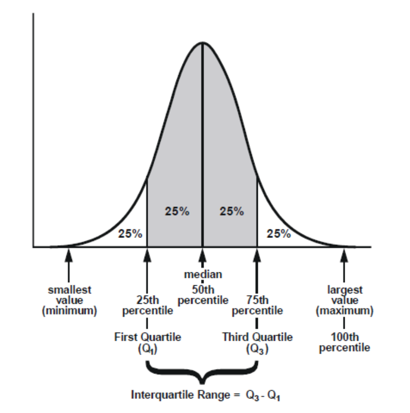

Q1, Q2, Q3, and IQR are all measures of position that divide a dataset into groups, providing insights into the distribution and spread of the data. Here's the significance of each:

1. Q1 (First Quartile):
- Marks the 25th percentile of the data.
- 25% of the values in the dataset fall below Q1.
- Helps identify the lower end of the data's spread.
2. Q2 (Second Quartile/Median):
- Marks the 50th percentile of the data.
- Divides the data in half, with 50% of values falling below and 50% above.
- Represents the middle value of the dataset.
3. Q3 (Third Quartile):
- Marks the 75th percentile of the data.
- 75% of the values in the dataset fall below Q3.
- Helps identify the upper end of the data's spread.
4. IQR (Interquartile Range):
- Calculated as Q3 - Q1.
- Represents the range of the middle 50% of the data.
- Less affected by extreme values (outliers) than the overall range.

Used to:

- Identify potential outliers.
- Understand the variability of the data.
- Construct box plots for visualizing the distribution.

Overall Significance:

- Provide a more detailed picture of the data's distribution than just the mean or median.
- Help identify where the majority of the data lies.
- Useful for comparing distributions across different datasets.
- Essential for understanding the spread and variability of data.

```python
# Quartile analysis of the numerical variables
print('Bottom 1 percentile of Age:' , df['Age'].quantile(0.01))
print('Bottom 5 percentile of Age:' , df['Age'].quantile(0.05))
print('Bottom 10 percentile of Age:' , df['Age'].quantile(0.10))
print('Quartile 1 of Age:' , df['Age'].quantile(0.25))
print('Quartile 2 of Age:' , df['Age'].quantile(0.50))
print('Quartile 3 of Age:' , df['Age'].quantile(0.75))
print('Inter Quartile Range of Age:' , (df['Age'].quantile(0.75)-df['Age'].quantile(0.25)))
print('Top 10 percentile of Age:' , df['Age'].quantile(0.90))
print('Top 5 percentile of Age:' , df['Age'].quantile(0.95))
print('Top 1 percentile of Age:' , df['Age'].quantile(0.99))
print('='*100)
print('Bottom 1 percentile of fnlwgt:' , df['fnlwgt'].quantile(0.01))
print('Bottom 5 percentile of fnlwgt:' , df['fnlwgt'].quantile(0.05))
print('Bottom 10 percentile of fnlwgt:' , df['fnlwgt'].quantile(0.10))
print('Quartile 1 of fnlwgt:' , df['fnlwgt'].quantile(0.25))
print('Quartile 2 of fnlwgt:' , df['fnlwgt'].quantile(0.50))
print('Quartile 3 of fnlwgt:' , df['fnlwgt'].quantile(0.75))
print('Inter Quartile Range of fnlwgt:' , (df['fnlwgt'].quantile(0.75)-df['fnlwgt'].quantile(0.25)))
print('Top 10 percentile of fnlwgt:' , df['fnlwgt'].quantile(0.90))
print('Top 5 percentile of fnlwgt:' , df['fnlwgt'].quantile(0.95))
print('Top 1 percentile of fnlwgt:' , df['fnlwgt'].quantile(0.99))
print('='*100)
print('Bottom 1 percentile of Education-Num:' , df['Education-Num'].quantile(0.01))
print('Bottom 5 percentile of Education-Num:' , df['Education-Num'].quantile(0.05))
print('Bottom 10 percentile of Education-Num:' , df['Education-Num'].quantile(0.10))
print('Quartile 1 of Education-Num:' , df['Education-Num'].quantile(0.25))
print('Quartile 2 of Education-Num:' , df['Education-Num'].quantile(0.50))
print('Quartile 3 of Education-Num:' , df['Education-Num'].quantile(0.75))
print('Inter Quartile Range of Education-Num:' , (df['Education-Num'].quantile(0.75)-df['Education-Num'].quantile(0.25)))
print('Top 10 percentile of Education-Num:' , df['Education-Num'].quantile(0.90))
print('Top 5 percentile of Education-Num:' , df['Education-Num'].quantile(0.95))
print('Top 1 percentile of Education-Num:' , df['Education-Num'].quantile(0.99))
print('='*100)
print('Bottom 1 percentile of Capital Gain:' , df['Capital Gain'].quantile(0.01))
print('Bottom 5 percentile of Capital Gain:' , df['Capital Gain'].quantile(0.05))
print('Bottom 10 percentile of Capital Gain:' , df['Capital Gain'].quantile(0.10))
print('Quartile 1 of Capital Gain:' , df['Capital Gain'].quantile(0.25))
print('Quartile 2 of Capital Gain:' , df['Capital Gain'].quantile(0.50))
print('Quartile 3 of Capital Gain:' , df['Capital Gain'].quantile(0.75))
print('Inter Quartile Range of Capital Gain:' , (df['Capital Gain'].quantile(0.75)-df['Capital Gain'].quantile(0.25)))
print('Top 10 percentile of Capital Gain:' , df['Capital Gain'].quantile(0.90))
print('Top 5 percentile of Capital Gain:' , df['Capital Gain'].quantile(0.95))
print('Top 1 percentile of Capital Gain:' , df['Capital Gain'].quantile(0.99))
print('='*100)
print('Bottom 1 percentile of Capital Loss:' , df['Capital Loss'].quantile(0.01))
print('Bottom 5 percentile of Capital Loss:' , df['Capital Loss'].quantile(0.05))
print('Bottom 10 percentile of Capital Loss:' , df['Capital Loss'].quantile(0.10))
print('Quartile 1 of Capital Loss:' , df['Capital Loss'].quantile(0.25))
print('Quartile 2 of Capital Loss:' , df['Capital Loss'].quantile(0.50))
print('Quartile 3 of Capital Loss:' , df['Capital Loss'].quantile(0.75))
print('Inter Quartile Range of Capital Loss:' , (df['Capital Loss'].quantile(0.75)-df['Capital Loss'].quantile(0.25)))
print('Top 10 percentile of Capital Loss:' , df['Capital Loss'].quantile(0.90))
print('Top 5 percentile of Capital Loss:' , df['Capital Loss'].quantile(0.95))
print('Top 1 percentile of Capital Loss:' , df['Capital Loss'].quantile(0.99))
print('='*100)
print('Bottom 1 percentile of Hours per week:' , df['Hours per week'].quantile(0.01))
print('Bottom 5 percentile of Hours per week:' , df['Hours per week'].quantile(0.05))
print('Bottom 10 percentile of Hours per week:' , df['Hours per week'].quantile(0.10))
print('Quartile 1 of Hours per week:' , df['Hours per week'].quantile(0.25))
print('Quartile 2 of Hours per week:' , df['Hours per week'].quantile(0.50))
print('Quartile 3 of Hours per week:' , df['Hours per week'].quantile(0.75))
print('Inter Quartile Range of Hours per week:' , (df['Hours per week'].quantile(0.75)-df['Hours per week'].quantile(0.25)))
print('Top 10 percentile of Hours per week:' , df['Hours per week'].quantile(0.90))
print('Top 5 percentile of Hours per week:' , df['Hours per week'].quantile(0.95))
print('Top 1 percentile of Hours per week:' , df['Hours per week'].quantile(0.99))
```

```
Bottom 1 percentile of Age: 17.0
Bottom 5 percentile of Age: 19.0
Bottom 10 percentile of Age: 22.0
Quartile 1 of Age: 28.0
Quartile 2 of Age: 37.0
Quartile 3 of Age: 48.0
Inter Quartile Range of Age: 20.0
Top 10 percentile of Age: 58.0
Top 5 percentile of Age: 63.0
Top 1 percentile of Age: 74.0
====================================================================================================
Bottom 1 percentile of fnlwgt: 27185.8
Bottom 5 percentile of fnlwgt: 39460.0
Bottom 10 percentile of fnlwgt: 65716.0
Quartile 1 of fnlwgt: 117827.0
Quartile 2 of fnlwgt: 178356.0
Quartile 3 of fnlwgt: 237051.0
Inter Quartile Range of fnlwgt: 119224.0
Top 10 percentile of fnlwgt: 329054.0
Top 5 percentile of fnlwgt: 379682.0
Top 1 percentile of fnlwgt: 510072.0
====================================================================================================
Bottom 1 percentile of Education-Num: 3.0
Bottom 5 percentile of Education-Num: 5.0
Bottom 10 percentile of Education-Num: 7.0
Quartile 1 of Education-Num: 9.0
Quartile 2 of Education-Num: 10.0
Quartile 3 of Education-Num: 12.0
Inter Quartile Range of Education-Num: 3.0
Top 10 percentile of Education-Num: 13.0
Top 5 percentile of Education-Num: 14.0
Top 1 percentile of Education-Num: 16.0
====================================================================================================
Bottom 1 percentile of Capital Gain: 0.0
Bottom 5 percentile of Capital Gain: 0.0
Bottom 10 percentile of Capital Gain: 0.0
Quartile 1 of Capital Gain: 0.0
Quartile 2 of Capital Gain: 0.0
Quartile 3 of Capital Gain: 0.0
Inter Quartile Range of Capital Gain: 0.0
```

[output cut: 10 more lines]

```
Inter Quartile Range of Capital Loss: 0.0
Top 10 percentile of Capital Loss: 0.0
Top 5 percentile of Capital Loss: 0.0
Top 1 percentile of Capital Loss: 1980.0
====================================================================================================
Bottom 1 percentile of Hours per week: 8.0
Bottom 5 percentile of Hours per week: 18.0
Bottom 10 percentile of Hours per week: 24.0
Quartile 1 of Hours per week: 40.0
Quartile 2 of Hours per week: 40.0
Quartile 3 of Hours per week: 45.0
Inter Quartile Range of Hours per week: 5.0
Top 10 percentile of Hours per week: 55.0
Top 5 percentile of Hours per week: 60.0
Top 1 percentile of Hours per week: 80.0
```

### Interpretation

1. Age
- Overall Range & Concentration: The data shows a wide range of ages, from 17 years for the youngest 1% to 74 years for the oldest 1%.
- Typical Age Group: The middle 50% of individuals are between 28 and 48 years old (IQR = 20 years), with half of the dataset being 37 years old or younger.
- Early Career Focus: 10% of the individuals are 22 years old or younger, indicating a significant portion of younger participants.
- Elderly Representation: Only 5% of individuals are 63 years or older, and 1% are 74 years or older, suggesting fewer very elderly participants.
2. fnlwgt
- Wide Spread: The fnlwgt (final weight) values exhibit an extremely wide distribution, with an Interquartile Range (IQR) of 119,224. This signifies significant variability in the number of people each record represents.
- Lower Quartile: 25% of the records have a fnlwgt of 117,827 or less, while 1% are as low as 27,185.8.
- Upper Quartile: 25% of the records have a fnlwgt of 237,051 or more, with the top 1% reaching 510,072.
- Median Value: The median fnlwgt is 178,356, around which the central half of the data is distributed.
3. Education-Num
- Concentrated Distribution: Education levels are relatively clustered, with an IQR of only 3.0.
- Majority at Standard Levels: Half of the individuals have completed between 9 and 12 years of education, with the median being 10 years (often corresponding to high school or some college).
- Lower Education: 10% have 7 years of education or less, and 1% have only 3 years, suggesting a small segment with very limited formal education.
- Higher Education: Conversely, 10% have 13 years of education or more, and 1% reach 16 years, indicating a smaller segment with advanced education (e.g., Bachelor's degree and above).
4. Capital Gain
- Extreme Right Skew: The distribution of Capital Gain is highly skewed towards zero. The bottom 75% (Quartile 3) of individuals have a Capital Gain of 0.0. This means the vast majority of people in the dataset experienced no capital gains.
- Significant Outliers/Spikes: Only the top 5% show non-zero capital gains (5013.0 or more), and the top 1% have gains of 15024.0 or more. This indicates that capital gains, when they occur, are often substantial for a very small fraction of the population.
- Zero IQR: An IQR of 0.0 further confirms that the middle 50% of the data is entirely concentrated at zero.
5. Capital Loss
- Extreme Right Skew (Even More Pronounced): Similar to Capital Gain, Capital Loss is even more heavily concentrated at 0.0. The bottom 95% of individuals (and up to the top 5%) have experienced no capital losses.
- Rare, Large Losses: Only the top 1% show any non-zero capital loss, with values of 1980.0 or more. This implies that capital losses are extremely rare in this dataset, and when they do occur, they can be significant for a tiny minority.
- Zero IQR: The IQR of 0.0, along with many percentiles being 0, confirms that capital losses are virtually non-existent for the overwhelming majority of the dataset.
6. Hours per week
- Concentration at Full-Time: The median and Quartile 1 are both 40.0 hours, indicating that at least half of the individuals work exactly 40 hours per week, and a large portion of the lower half also works 40 hours.
- Relatively Tight Spread Around 40: The IQR is 5.0, meaning the middle 50% of the workforce works between 40 and 45 hours per week, highlighting a strong clustering around standard full-time employment.
- Part-Time & Overtime: There's a segment working fewer hours (10% work 24 hours or less, 1% works 8 hours or less), and also a segment working more (10% work 55 hours or more, with the top 1% reaching 80 hours per week).

### Efficient coding through Loops ( Quartile Analysis )

```python
# --- Define the numerical columns you want to analyze ---
numerical_cols = ['Age', 'fnlwgt', 'Education-Num', 'Capital Gain', 'Capital Loss', 'Hours per week']

# --- Define the percentiles/quartiles you want to calculate ---
quantiles_to_calculate = {
    0.01: 'Bottom 1 percentile',
    0.05: 'Bottom 5 percentile',
    0.10: 'Bottom 10 percentile',
    0.25: 'Quartile 1',
    0.50: 'Quartile 2',
    0.75: 'Quartile 3',
    0.90: 'Top 10 percentile',
    0.95: 'Top 5 percentile',
    0.99: 'Top 1 percentile'
}

print("--- Quartile Analysis of Numerical Variables ---")

# Loop through each numerical column
for col in numerical_cols:
    print(f"\nAnalysis for: {col}")

    # Loop through the defined quantiles
    for q_value, q_label in quantiles_to_calculate.items():
        percentile_value = df[col].quantile(q_value)
        print(f"{q_label} of {col}: {percentile_value}")

    # Calculate and print the Inter Quartile Range (IQR) separately
    q1 = df[col].quantile(0.25)
    q3 = df[col].quantile(0.75)
    iqr = q3 - q1
    print(f"Inter Quartile Range of {col}: {iqr}")

    print('='*100) # Separator for readability
```

```
--- Quartile Analysis of Numerical Variables ---

Analysis for: Age
Bottom 1 percentile of Age: 17.0
Bottom 5 percentile of Age: 19.0
Bottom 10 percentile of Age: 22.0
Quartile 1 of Age: 28.0
Quartile 2 of Age: 37.0
Quartile 3 of Age: 48.0
Top 10 percentile of Age: 58.0
Top 5 percentile of Age: 63.0
Top 1 percentile of Age: 74.0
Inter Quartile Range of Age: 20.0
====================================================================================================

Analysis for: fnlwgt
Bottom 1 percentile of fnlwgt: 27185.8
Bottom 5 percentile of fnlwgt: 39460.0
Bottom 10 percentile of fnlwgt: 65716.0
Quartile 1 of fnlwgt: 117827.0
Quartile 2 of fnlwgt: 178356.0
Quartile 3 of fnlwgt: 237051.0
Top 10 percentile of fnlwgt: 329054.0
Top 5 percentile of fnlwgt: 379682.0
Top 1 percentile of fnlwgt: 510072.0
Inter Quartile Range of fnlwgt: 119224.0
====================================================================================================

Analysis for: Education-Num
Bottom 1 percentile of Education-Num: 3.0
Bottom 5 percentile of Education-Num: 5.0
Bottom 10 percentile of Education-Num: 7.0
Quartile 1 of Education-Num: 9.0
Quartile 2 of Education-Num: 10.0
Quartile 3 of Education-Num: 12.0
Top 10 percentile of Education-Num: 13.0
Top 5 percentile of Education-Num: 14.0
Top 1 percentile of Education-Num: 16.0
Inter Quartile Range of Education-Num: 3.0
====================================================================================================
```

[output cut: 24 more lines]

```
Inter Quartile Range of Capital Loss: 0.0
====================================================================================================

Analysis for: Hours per week
Bottom 1 percentile of Hours per week: 8.0
Bottom 5 percentile of Hours per week: 18.0
Bottom 10 percentile of Hours per week: 24.0
Quartile 1 of Hours per week: 40.0
Quartile 2 of Hours per week: 40.0
Quartile 3 of Hours per week: 45.0
Top 10 percentile of Hours per week: 55.0
Top 5 percentile of Hours per week: 60.0
Top 1 percentile of Hours per week: 80.0
Inter Quartile Range of Hours per week: 5.0
====================================================================================================
```

### E. Standard Error of the Mean (SEM)

The Standard Error of the Mean (SEM) is a statistical measure that quantifies the accuracy with which a sample mean represents the true population mean.

In simpler terms, if you were to take many different samples from the same population and calculate the mean for each sample, the SEM tells you how much those sample means are likely to vary from the actual mean of the entire population. A smaller SEM indicates that the sample mean is a more precise estimate of the population mean.

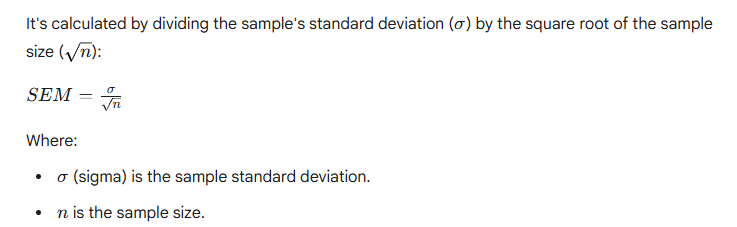

Key points about SEM:

Measure of Precision: It's a measure of the precision of the sample mean, not the variability of the individual data points themselves (that's what standard deviation measures). Decreases with Sample Size: As the sample size (n) increases, the SEM decreases. This makes intuitive sense: larger samples generally provide a more reliable estimate of the population mean. Used for Confidence Intervals: SEM is often used to calculate confidence intervals for the population mean, which provide a range within which the true population mean is likely to fall.

```python
print('SEM of Age:' , round(df['Age'].sem(),2))
print('SEM of fnlwgt:' , round(df['fnlwgt'].sem(),2))
print('SEM of Education-Num:' , round(df['Education-Num'].sem(),2))
print('SEM of Capital Gain:' , round(df['Capital Gain'].sem(),2))
print('SEM of Capital Loss:' , round(df['Capital Loss'].sem(),2))
print('SEM of Hours per week:' , round(df['Hours per week'].sem(),2))
```

```
SEM of Age: 0.08
SEM of fnlwgt: 584.94
SEM of Education-Num: 0.01
SEM of Capital Gain: 40.93
SEM of Capital Loss: 2.23
SEM of Hours per week: 0.07
```

### Interpretation

- SEM of Age: 0.08
  - This extremely small SEM suggests that the calculated sample mean age (around 38.6 years) is a highly precise estimate of the true average age in the larger population from which this dataset was drawn. There's very little expected variability if you were to draw multiple samples of the same size.
- SEM of fnlwgt: 584.94
  - This is a relatively large SEM. It indicates that the sample mean fnlwgt (around 189,778) is a less precise estimate of the population mean fnlwgt. This larger error is likely due to the inherent wide variability and range present in the fnlwgt values themselves.
- SEM of Education-Num: 0.01
  - This incredibly small SEM implies that the sample mean education level (around 10.1 years) is an extremely precise and reliable estimate of the true average education level in the population. The sample mean is expected to be very close to the population mean.
- SEM of Capital Gain: 40.93
  - This indicates a moderately sized SEM. Given the highly skewed nature of Capital Gain data (where most values are zero, but a few are very large), this suggests that the sample mean capital gain is a less precise estimate of the true population mean. The high variability in the data contributes to this larger standard error.
- SEM of Capital Loss: 2.23
  - This is a relatively small SEM. While Capital Loss also has many zero values, its overall variability is lower than Capital Gain. This SEM suggests a reasonably precise estimate of the population mean capital loss, though the skewness still means the mean might not be the "typical" value.
- SEM of Hours per week: 0.07
  - This very small SEM indicates that the sample mean hours per week (around 40.4 hours) is a highly precise estimate of the true average hours worked per week in the population. The sample mean is a very reliable indicator of the population average.

In summary: A smaller SEM signifies a more reliable and precise estimate of the population mean based on your sample data. Variables with high intrinsic variability (like fnlwgt, Capital Gain) tend to have higher SEMs, reflecting more uncertainty in their mean estimates.

# 5. Statistical Analysis - Understanding of Distribution

A distribution in statistics describes the arrangement of data points, showing how frequently each value or range of values appears within a dataset. Understanding a distribution is crucial because it provides fundamental insights into the nature of the data: it reveals where data is concentrated (central tendency), how spread out it is (variability), whether it's symmetrical or skewed, and if outliers exist. This knowledge is essential for choosing appropriate statistical methods, making informed interpretations, identifying patterns or anomalies, and building more accurate models, ultimately guiding better decision-making from the data.

### A. Skewness -

Skewness is a measure of the asymmetry of the distribution of a dataset. Here's how it's calculated:

Calculate the Mean (μ):

Find the average of all the values in the dataset.

Calculate the Standard Deviation (σ):

A measure of how spread out the data is around the mean (see previous explanations for how to calculate this).

Calculate the Skewness: This involves calculating the third standardized moment. Here's the formula:

Skewness = Σ(xi - μ)³ / (N * σ³)

Where:

- xi = each value in the dataset
- μ = the mean of the dataset
- σ = the standard deviation of the dataset
- N = the number of values in the dataset

Interpretation:

- Skewness = 0: The distribution is perfectly symmetrical.
- Skewness > 0 (Positive Skew): The distribution has a longer tail on the right side. The mean is greater than the median.
- Skewness < 0 (Negative Skew): The distribution has a longer tail on the left side. The mean is less than the median.

In simpler terms:

Imagine a bell curve. If the bell curve is stretched towards the right, it's positively skewed. If it's stretched towards the left, it's negatively skewed.

Why is skewness important?

- It helps understand the shape of the data distribution.
- Many statistical models assume a normal distribution (symmetrical). Skewness helps assess if this assumption is valid.
- It can influence the choice of appropriate summary statistics (mean vs. median).

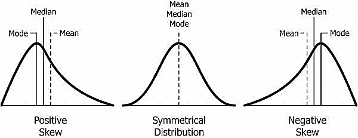

```python
print('Skewness of Age:' , df['Age'].skew())
print('Skewness of fnlwgt:' , df['fnlwgt'].skew())
print('Skewness of Education-Num:' , df['Education-Num'].skew())
print('Skewness of Capital Gain:' , df['Capital Gain'].skew())
print('Skewness of Capital Loss:' , df['Capital Loss'].skew())
print('Skewness of Hours per week:' , df['Hours per week'].skew())
```

```
Skewness of Age: 0.5587433694130484
Skewness of fnlwgt: 1.4469800945789826
Skewness of Education-Num: -0.3116758679102297
Skewness of Capital Gain: 11.953847687699799
Skewness of Capital Loss: 4.594629121679692
Skewness of Hours per week: 0.22764253680450092
```

### Interpretation

- Skewness of Age: 0.559
  - This indicates a moderately positive (right) skew. This means that the tail of the age distribution is longer on the right side, suggesting there are more younger individuals, but also a notable presence of older individuals (who pull the average up) compared to a perfectly symmetrical distribution. The mean age is slightly higher than the median age.
- Skewness of fnlwgt: 1.447
  - This shows a highly positive (right) skew. This is a very strong skewness, implying that the vast majority of fnlwgt values are concentrated on the lower end, while there are a few extremely large fnlwgt values that pull the mean significantly higher than the median.
- Skewness of Education-Num: -0.312
  - This indicates a slightly negative (left) skew. This means the tail of the distribution is longer on the left side, suggesting a concentration of individuals with higher education numbers, with fewer individuals having very low education numbers. It's closer to symmetrical than the positively skewed variables.
- Skewness of Capital Gain: 11.954
  - This is an extremely high positive (right) skew. This confirms what was seen in the median/percentile analysis: almost all values are zero, but there are a very small number of extremely large capital gains that create a very long tail to the right, heavily pulling the mean far beyond the median. The distribution is severely concentrated at the lower end.
- Skewness of Capital Loss: 4.595
  - This shows a highly positive (right) skew. Similar to capital gain, the vast majority of values are zero, but there are a few significantly large capital losses that create a long tail to the right. The distribution is heavily concentrated at the lower end.
- Skewness of Hours per week: 0.228
  - This indicates a slight positive (right) skew. This suggests that while many people work around 40 hours, there's a slightly longer tail towards individuals working more than 40 hours per week, rather than fewer. The distribution is relatively close to symmetrical.

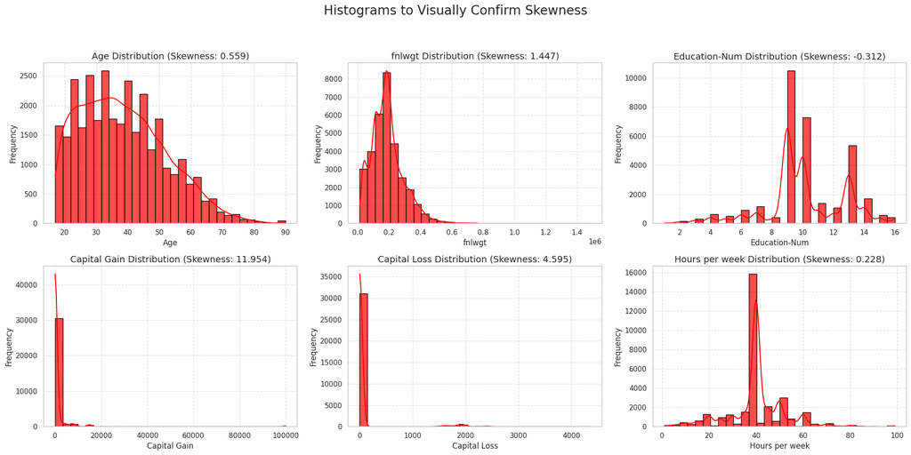

```python
import matplotlib.pyplot as plt
import seaborn as sns

# --- Define the numerical columns for which skewness was calculated ---
numerical_cols = ['Age', 'fnlwgt', 'Education-Num', 'Capital Gain', 'Capital Loss', 'Hours per week']

# Calculate skewness for confirmation
skewness_results = df[numerical_cols].skew()

# Set plot style
sns.set_theme(style="whitegrid")

# Create a figure and a set of subplots
# We need 2 rows and 3 columns to fit 6 plots
fig, axes = plt.subplots(nrows=2, ncols=3, figsize=(20, 10))
axes = axes.flatten() # Flatten the 2x3 array of axes into a 1D array for easy iteration

fig.suptitle('Histograms to Visually Confirm Skewness', fontsize=20, y=1.02) # Main title for the figure

# Loop through each numerical column and plot its histogram
for i, col in enumerate(numerical_cols):
    sns.histplot(data=df, x=col, kde=True, ax=axes[i], bins=30, edgecolor='black', alpha=0.7 , color='red')
    axes[i].set_title(f'{col} Distribution (Skewness: {skewness_results[col]:.3f})', fontsize=14)
    axes[i].set_xlabel(col, fontsize=12)
    axes[i].set_ylabel('Frequency', fontsize=12)
    axes[i].grid(True, linestyle='--', alpha=0.6)

plt.tight_layout(rect=[0, 0.03, 1, 0.98]) # Adjust layout to prevent titles/labels overlapping with suptitle
plt.show()
```

### B. Kurtosis

Kurtosis is a measure of the "tailedness" and peakedness of the distribution of a dataset. Here's how it's calculated:

- Calculate the Mean (μ):
- Find the average of all the values in the dataset.

Calculate the Standard Deviation (σ):

- A measure of how spread out the data is around the mean.

Calculate the Kurtosis:

This involves calculating the fourth standardized moment. Here's the formula:

Kurtosis = Σ(xi - μ)⁴ / (N * σ⁴)

Where:

- xi = each value in the dataset
- μ = the mean of the dataset
- σ = the standard deviation of the dataset
- N = the number of values in the dataset

Interpretation:

- Kurtosis = 3 (or 0 in some normalizations): The distribution is mesokurtic, similar to a normal distribution.
- Kurtosis > 3 (Leptokurtic): The distribution has heavier tails and a sharper peak than a normal distribution. The data is more concentrated around the mean, with more outliers.
- Kurtosis < 3 (Platykurtic): The distribution has lighter tails and a flatter peak than a normal distribution. The data is less concentrated around the mean.

In simpler terms:

- Imagine a bell curve.
- A leptokurtic distribution is like a tall, skinny bell with long tails.
- A platykurtic distribution is like a wide, flat bell with short tails.

Why is kurtosis important?

It helps understand the shape of the data distribution, particularly how extreme values are distributed. It can indicate the presence of outliers. It's used in various statistical tests and models.

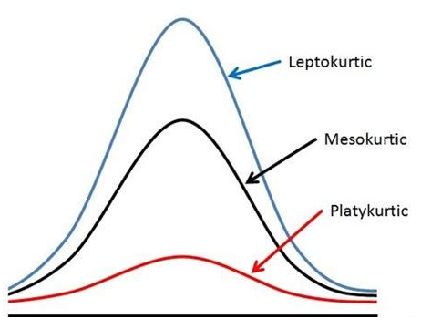

```python
print('Kurtosis of Age:' , df['Age'].kurt())
print('Kurtosis of fnlwgt:' , df['fnlwgt'].kurt())
print('Kurtosis of Education-Num:' , df['Education-Num'].kurt())
print('Kurtosis of Capital Gain:' , df['Capital Gain'].kurt())
print('Kurtosis of Capital Loss:' , df['Capital Loss'].kurt())
print('Kurtosis of Hours per week:' , df['Hours per week'].kurt())
```

```
Kurtosis of Age: -0.16612745957143904
Kurtosis of fnlwgt: 6.218810978153801
Kurtosis of Education-Num: 0.6234440747629248
Kurtosis of Capital Gain: 154.79943785425334
Kurtosis of Capital Loss: 20.3768017134122
Kurtosis of Hours per week: 2.916686796002066
```

# 6. Statistical Analysis - Pairwise relationship

A pairwise relationship in a dataset refers to the association or connection observed between any two individual variables within that dataset, examined independently of all other variables. It describes how changes in one variable correspond to changes in another, indicating patterns such as positive or negative correlation, or the absence of any linear or monotonic trend, when considering only those two variables at a time.

### A. Covariance

Covariance is a statistical measure that describes the directional relationship between two random variables. It tells us whether two variables tend to move in the same direction, in opposite directions, or if there's no consistent linear relationship between them.

- Positive Covariance: If the covariance is positive, it means that as one variable increases, the other variable also tends to increase. Similarly, if one decreases, the other tends to decrease. They move in the same direction.
- Negative Covariance: If the covariance is negative, it means that as one variable increases, the other variable tends to decrease, and vice-versa. They move in opposite directions.
- Near-Zero Covariance: If the covariance is close to zero, it suggests that there is no strong linear relationship between the two variables. They might move independently, or there might be a non-linear relationship that covariance doesn't capture.

Example:

Let's consider a simple dataset for a few students, looking at two variables: Daily Hours Spent Studying and their Exam Score.

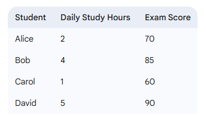

Export to Sheets If we were to calculate the covariance between "Daily Study Hours" and "Exam Score" for these students, we would likely find a positive covariance. This is because, generally, as the number of study hours increases (from Alice to Bob, Carol to David), the exam score also tends to increase. They show a consistent pattern of moving in the same direction.

If, however, we were comparing "Hours Spent Watching TV" and "Exam Score," we might find a negative covariance, implying that as TV watching increases, exam scores tend to decrease.

```python
round((df.select_dtypes(include='number')).cov(),2)
```

|  | Age | fnlwgt | Education-Num | Capital Gain | Capital Loss | Hours per week |
| --- | --- | --- | --- | --- | --- | --- |
| Age | 186.06 | -1.103507e+05 | 1.28 | 7824.82 | 317.56 | 11.58 |
| fnlwgt | -110350.69 | 1.114080e+10 | -11729.53 | 336662.50 | -436030.33 | -24460.43 |
| Education-Num | 1.28 | -1.172953e+04 | 6.62 | 2330.01 | 82.86 | 4.71 |
| Capital Gain | 7824.82 | 3.366625e+05 | 2330.01 | 54542539.18 | -94085.76 | 7150.03 |
| Capital Loss | 317.56 | -4.360303e+05 | 82.86 | -94085.76 | 162376.94 | 269.95 |
| Hours per week | 11.58 | -2.446043e+04 | 4.71 | 7150.03 | 269.95 | 152.46 |

### Interpretation

Here's a breakdown of key relationships:

1. Age and Hours per week (Covariance: 11.58):
- There is a small positive covariance between Age and Hours per week. This suggests that, generally, as individuals get older, they tend to work slightly more hours per week, or vice-versa. The relationship is weak given the scale.
2. Age and Capital Gain (Covariance: 7824.82): *There is a moderate positive covariance. This implies that older individuals tend to have higher capital gains. This makes intuitive sense, as capital gains often accumulate over time.
3. Age and Capital Loss (Covariance: 317.56):
- There is a small positive covariance. This indicates that older individuals also tend to have slightly higher capital losses. Given the extreme skewness of capital loss, this might be driven by a few older individuals with large losses.
4. fnlwgt and Education-Num (Covariance: -11729.53):
- There is a negative covariance. This suggests that as fnlwgt (the number of people a record represents) increases, the Education-Num tends to decrease, or vice-versa. This might imply that records representing larger groups tend to have lower average educational attainment, or there's some complex sampling dynamic.
5. Capital Gain and Capital Loss (Covariance: -94085.76):
- There is a negative covariance. This means that individuals who experience higher capital gains tend to have lower capital losses, and vice versa. This makes sense as these are opposing financial outcomes; it's less common to have both large gains and large losses in the same period.
6. Capital Gain and Hours per week (Covariance: 7150.03):
- There is a moderate positive covariance. This implies that individuals who work more hours per week tend to have higher capital gains. This could be due to higher income leading to more investment, or simply more engagement in activities that generate capital gains.

Important Note: While covariance tells us the direction, its numerical value is not standardized. To understand the strength of the linear relationship, you would need to look at the correlation coefficient, which scales covariance between -1 and 1. For example, a covariance of 7824.82 for Age and Capital Gain looks large, but without knowing the standard deviations of both, we can't definitively say if it's a "strong" relationship.

### B. Correlation

Correlation is a statistical measure that quantifies the strength and direction of a linear relationship between two numerical variables. Unlike covariance, correlation is standardized, meaning its value always falls within a specific range, making it much easier to interpret.

The correlation coefficient (often denoted as 'r' or 'ρ') ranges from -1 to +1:

- +1 (Perfect Positive Correlation): As one variable increases, the other variable increases proportionally in the same direction. All data points would fall perfectly on an upward-sloping straight line.
- -1 (Perfect Negative Correlation): As one variable increases, the other variable decreases proportionally. All data points would fall perfectly on a downward-sloping straight line.
- 0 (No Linear Correlation): There is no consistent linear relationship between the two variables. Changes in one variable do not predict consistent changes in the other. (Important: This doesn't mean there's no relationship at all, just no linear one; there could be a non-linear pattern).
- Values between 0 and +1 (Positive Correlation): A positive relationship exists, but it's not perfect. Higher values closer to +1 indicate a stronger positive linear relationship.
- Values between -1 and 0 (Negative Correlation): A negative relationship exists, but it's not perfect. Lower values closer to -1 indicate a stronger negative linear relationship.

DIFFERENT TYPES OF CORRELATION -

1. Pearson Correlation Coefficient (Pearson's r)
- What it Measures: Pearson correlation measures the strength and direction of a linear relationship between two continuous numerical variables. It assesses how well a straight line can describe the relationship between two variables.

Key Characteristics/Assumptions:

- Linearity: Assumes the relationship between the variables is linear. Continuous Data: Both variables should be measured on an interval or ratio scale (e.g., temperature, height, income).
- Normality (for inference): For hypothesis testing and confidence intervals, it assumes that the data for each variable is approximately normally distributed.
- Homoscedasticity: Assumes the variance of one variable is roughly equal across all levels of the other variable.
- Sensitivity to Outliers: Pearson correlation can be heavily influenced by outliers, which can distort the true relationship.
- When to Use It: When you want to find out if there's a straight-line relationship between two numerical variables that are approximately normally distributed, and you are confident there are no extreme outliers pulling the relationship.
- Example: The linear relationship between a person's height and their weight, or between advertising spending and sales revenue.
2. Spearman's Rank Correlation Coefficient (Spearman's ρ )
- What it Measures: Spearman correlation measures the strength and direction of a monotonic relationship between two variables. Instead of using the raw data values, it converts the data into ranks and then calculates the Pearson correlation on these ranks. A monotonic relationship means that as one variable increases, the other variable either consistently increases (but not necessarily linearly) or consistently decreases.

Key Characteristics/Assumptions:

- Monotonicity: The relationship must be monotonic (either consistently increasing or consistently decreasing), but not necessarily linear.
- Ordinal Data: Suitable for ordinal data (ranked data) or when interval/ratio data doesn't meet Pearson's assumptions (e.g., non-normal distribution, presence of outliers).
- Non-Parametric: It is a non-parametric test, meaning it doesn't assume any specific distribution for the data.
- Less Sensitive to Outliers: Because it uses ranks, it is less affected by extreme outliers compared to Pearson's correlation.
- When to Use It: When you have ordinal data, or when your numerical data is not normally distributed, or if you suspect a non-linear but consistent (monotonic) relationship, or when outliers are present.
- Example: The relationship between students' rank in class based on exam scores and their rank in popularity, or the relationship between a person's income bracket (ordinal) and their happiness score (ordinal).
3. Kendall's Tau Correlation Coefficient (Kendall's τ)
- What it Measures: Kendall's Tau is another non-parametric measure of the strength and direction of a monotonic relationship between two variables. Like Spearman, it works with ranks, but its calculation is based on the number of "concordant" and "discordant" pairs in the data.
- Concordant Pair: If (x1, y1) and (x2, y2) are two observations, they are concordant if (x1 < x2 and y1 < y2) or (x1 > x2 and y1 > y2).
- Discordant Pair: They are discordant if (x1 < x2 and y1 > y2) or (x1 > x2 and y1 < y2).

Key Characteristics/Assumptions:

- Monotonicity: Similar to Spearman, it assesses monotonic relationships.
- Non-Parametric: It's also a non-parametric test, robust to non-normal distributions and outliers.
- Interpretation: Kendall's Tau is often considered more robust and provides a more interpretable probability measure of concordance. Its values tend to be smaller than Spearman's for the same data.
- When to Use It: When you have ordinal data, especially when dealing with smaller sample sizes or data with many tied ranks. It's often preferred over Spearman when dealing with a large number of ties in the ranks.
- Example: Ranking of movie preferences by two different critics, or the agreement between two different methods of ranking job candidates.

In summary, Pearson measures linear relationships for continuous, normally distributed data. Spearman and Kendall both measure monotonic (rank-based) relationships and are more suitable for ordinal data, non-normally distributed data, or data with outliers. Kendall is often favored when dealing with tied ranks or smaller samples.

```python
# Correlation analysis using pearson correlation

(df.select_dtypes(include='number').corr(method='pearson'))
```

|  | Age | fnlwgt | Education-Num | Capital Gain | Capital Loss | Hours per week |
| --- | --- | --- | --- | --- | --- | --- |
| Age | 1.000000 | -0.076646 | 0.036527 | 0.077674 | 0.057775 | 0.068756 |
| fnlwgt | -0.076646 | 1.000000 | -0.043195 | 0.000432 | -0.010252 | -0.018768 |
| Education-Num | 0.036527 | -0.043195 | 1.000000 | 0.122630 | 0.079923 | 0.148123 |
| Capital Gain | 0.077674 | 0.000432 | 0.122630 | 1.000000 | -0.031615 | 0.078409 |
| Capital Loss | 0.057775 | -0.010252 | 0.079923 | -0.031615 | 1.000000 | 0.054256 |
| Hours per week | 0.068756 | -0.018768 | 0.148123 | 0.078409 | 0.054256 | 1.000000 |

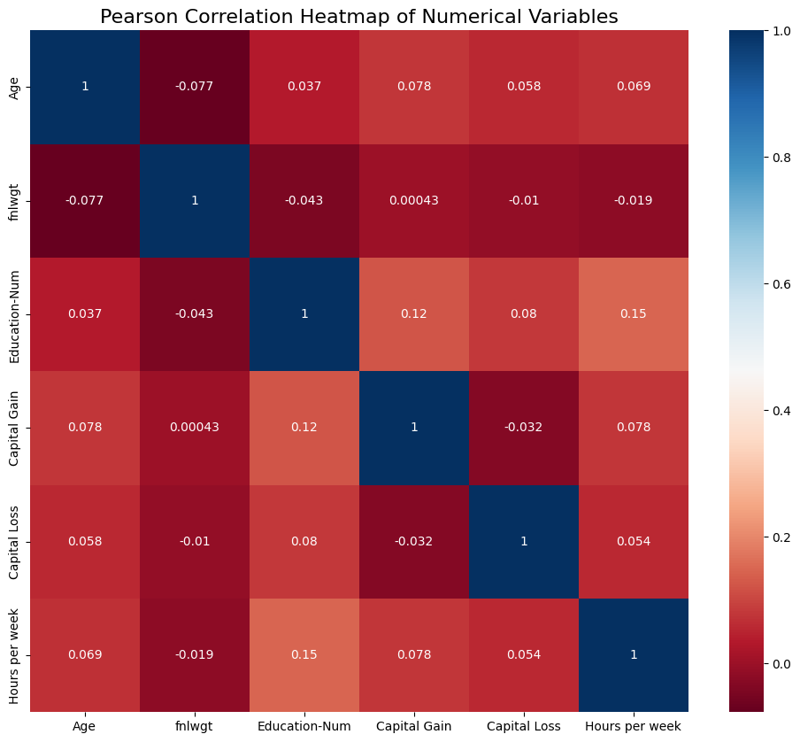

```python
# Correlation analysis using pearson correlation visualized as heatmap
import matplotlib.pyplot as plt
import seaborn as sns
plt.figure(figsize=(12, 10))
sns.heatmap((df.select_dtypes(include='number').corr(method='pearson')),annot=True , cmap='RdBu' )
plt.title('Pearson Correlation Heatmap of Numerical Variables', fontsize=16)
plt.show()
```

### Interpretation

This table displays the Pearson correlation coefficients between all pairs of numerical variables in your dataset. Remember that Pearson correlation measures the strength and direction of a linear relationship, with values ranging from -1 (perfect negative) to +1 (perfect positive), and 0 indicating no linear relationship.

Here's an interpretation of the key relationships:

- Age and Capital Gain (0.077674):
  - There is a very weak positive linear correlation between age and capital gain. This suggests that as age increases, capital gain tends to slightly increase, but the relationship is not strong. This aligns with the previous covariance interpretation, but now we know it's a very weak linear trend.
- Education-Num and Hours per week (0.148123):
  - There is a weak positive linear correlation between the number of years of education and hours worked per week. This indicates that individuals with more education tend to work slightly more hours, but it's not a strong dependency.
- Education-Num and Capital Gain (0.122630):
  - There is a weak positive linear correlation between education level and capital gain. This suggests that higher education is associated with slightly higher capital gains, but the relationship is not very strong.
- Capital Gain and Capital Loss (-0.031615):
  - There is a very weak negative linear correlation. This is an interesting finding. While intuitively one might expect a stronger negative relationship (as one is opposite to the other), the very low correlation indicates almost no linear relationship. This is likely heavily influenced by the fact that the vast majority of individuals have zero for both capital gain and capital loss, which significantly dampens the observed linear correlation. A non-linear or rank-based correlation (like Spearman/Kendall) might reveal more here.
- Most other correlations are very close to zero (e.g., fnlwgt with everything, Age with fnlwgt, etc.):
  - This indicates negligible to no linear relationship between these pairs of variables. For example, fnlwgt (final weight) shows very close to zero correlation with all other variables, suggesting it moves independently of age, education, capital, and hours worked per week.

Overall Interpretation:

- Most of the numerical variables in this dataset show very weak or negligible linear correlations with each other. The highest correlation observed is around 0.15, which is considered very weak.
- The results, especially for Capital Gain and Capital Loss, hint that a Pearson correlation might not be the most appropriate measure due to the highly skewed nature and the large number of zero values in these columns. For these variables, a non-parametric correlation method (like Spearman or Kendall) would likely provide more meaningful insights into their monotonic relationships, especially considering the large number of ties at zero.
- The generally low correlation values suggest that these numerical features are largely independent of each other in a linear fashion, or their relationships are primarily non-linear.

```python
# Correlation analysis using spearman correlation

(df.select_dtypes(include='number').corr(method='spearman'))
```

|  | Age | fnlwgt | Education-Num | Capital Gain | Capital Loss | Hours per week |
| --- | --- | --- | --- | --- | --- | --- |
| Age | 1.000000 | -0.078141 | 0.066345 | 0.124948 | 0.058484 | 0.142907 |
| fnlwgt | -0.078141 | 1.000000 | -0.035706 | -0.006039 | -0.006914 | -0.021621 |
| Education-Num | 0.066345 | -0.035706 | 1.000000 | 0.119140 | 0.074749 | 0.167215 |
| Capital Gain | 0.124948 | -0.006039 | 0.119140 | 1.000000 | -0.066569 | 0.093322 |
| Capital Loss | 0.058484 | -0.006914 | 0.074749 | -0.066569 | 1.000000 | 0.059852 |
| Hours per week | 0.142907 | -0.021621 | 0.167215 | 0.093322 | 0.059852 | 1.000000 |

```python
# Correlation analysis using kendall correlation

(df.select_dtypes(include='number').corr(method='kendall'))
```

|  | Age | fnlwgt | Education-Num | Capital Gain | Capital Loss | Hours per week |
| --- | --- | --- | --- | --- | --- | --- |
| Age | 1.000000 | -0.052811 | 0.053001 | 0.101126 | 0.047815 | 0.107891 |
| fnlwgt | -0.052811 | 1.000000 | -0.025765 | -0.004830 | -0.005591 | -0.015667 |
| Education-Num | 0.053001 | -0.025765 | 1.000000 | 0.103586 | 0.065498 | 0.131901 |
| Capital Gain | 0.101126 | -0.004830 | 0.103586 | 1.000000 | -0.064537 | 0.081215 |
| Capital Loss | 0.047815 | -0.005591 | 0.065498 | -0.064537 | 1.000000 | 0.052456 |
| Hours per week | 0.107891 | -0.015667 | 0.131901 | 0.081215 | 0.052456 | 1.000000 |